# Lab 4.1 - Plotting with `ggplot2`

Sherise Immanuela

Fall 2022

This document is a record of some basic ggplot2 exercises.

```r
library(tidyverse)
library(gapminder)
library(forcats)

# Put the data in the Environment
gapminder <- gapminder::gapminder

# Extract the data for the latest year in the dataset, for plots that don't involve year.
gapminder_latest <- filter(gapminder, year == 2007)
```

The `gapminder` tibble has 1704 observations. It contains all data from 1952 to 2007, so each country has multiple rows of data. The `gapminder_latest` tibble has 142 observations (142 countries). It only contains data for 2007, and each country has exactly one row of data.

## Styling and labeling plots

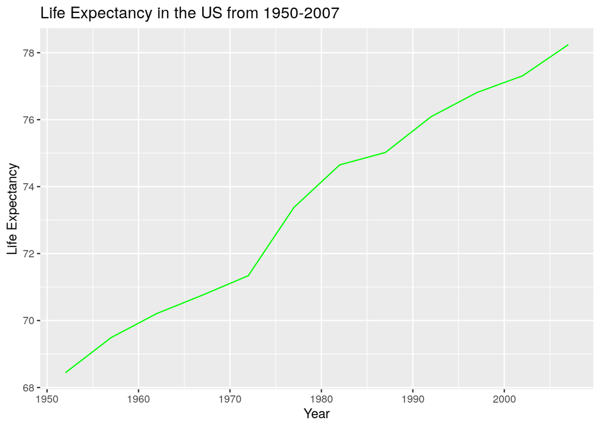

```r
gapminder %>%
  filter(country == "United States") %>%
  ggplot() +
  aes(x = year, y = lifeExp) +
  labs(x = "Year", y = "Life Expectancy", title = "Life Expectancy in the US from 1950-2007") +
  geom_line(color="green")
```

This visualization suggests that life expectancy has steadily increased year by year. In fact, life expectancy has increased by 10 years since 1950.

## Mapping vs Facetingy

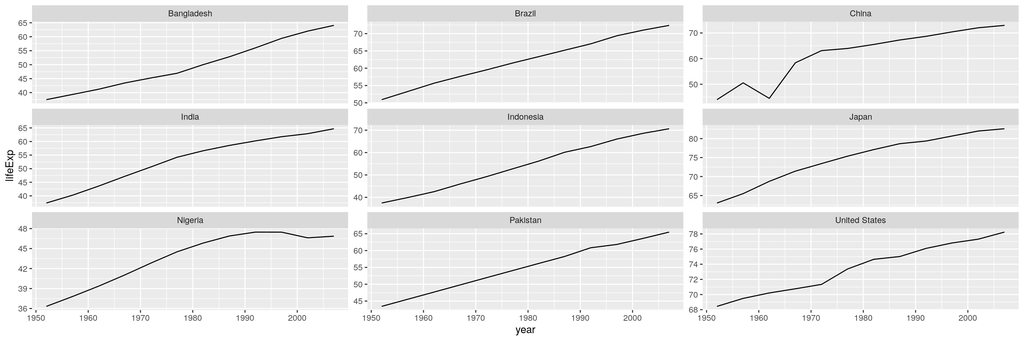

```r
countries <- c(
  "China", "India", "United States",
  "Indonesia", "Brazil", "Pakistan",
  "Bangladesh", "Nigeria", "Japan")

gapminder %>%
  filter(country %in% countries) %>%
  ggplot() +
  aes(x = year, y = lifeExp) +
  geom_line() +
  facet_wrap(vars(country), scales = "free_y")
```

The visualization suggests that all countries have had an increase in life expectancy over the years. It appears that Nigeria had a small decrease during 1990-2000. China also had a decrease during 1955-1960.

## Univariate analysis — Continuous

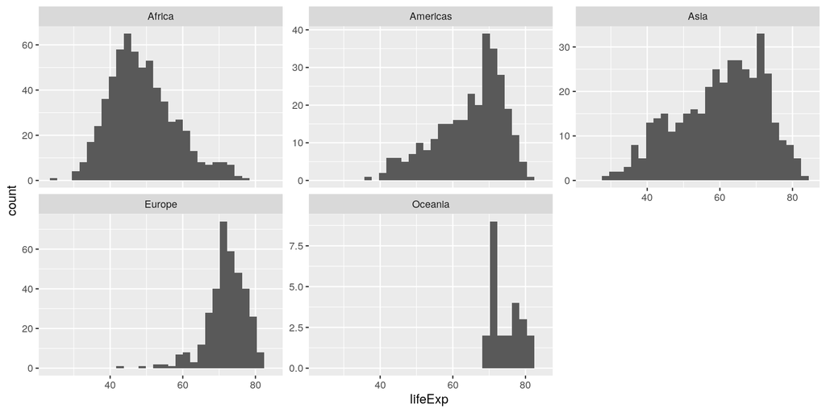

```r
gapminder %>%
  ggplot() +
  aes(x = lifeExp) +
  geom_histogram() +
  facet_wrap(vars(continent), scales = "free_y")
```

This graph attempts to explore the distribution of life expectancy in respect of continents. Americas, Asia, and America are more skewed to the left meaning life expectancy are at a higher level of occurrences at the high end of the distribution.

## Univariate Analysis — Categorical

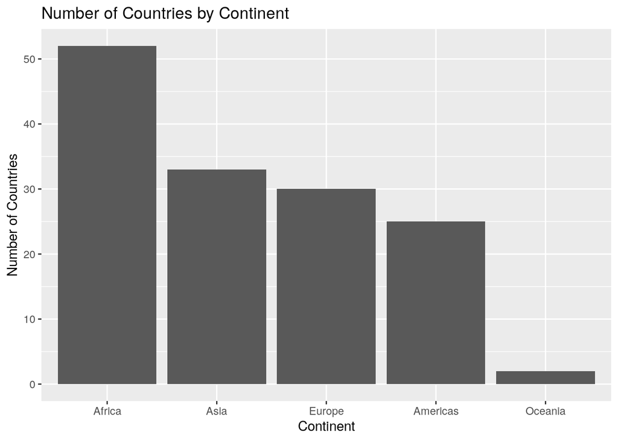

```r
gapminder_latest %>%
  ggplot() +
  aes(x = fct_infreq(continent)) +
  labs(x = "Continent", y = "Number of Countries", title = "Number of Countries by Continent") +
  geom_bar()
```

Africa is the continent that has the highest number of countries (over 50). Asia and Europe has similar numbers of countries (around 30). Oceania has the least number of countries (less than 5).

## Bivariate Analysis — Numerical/Categorical

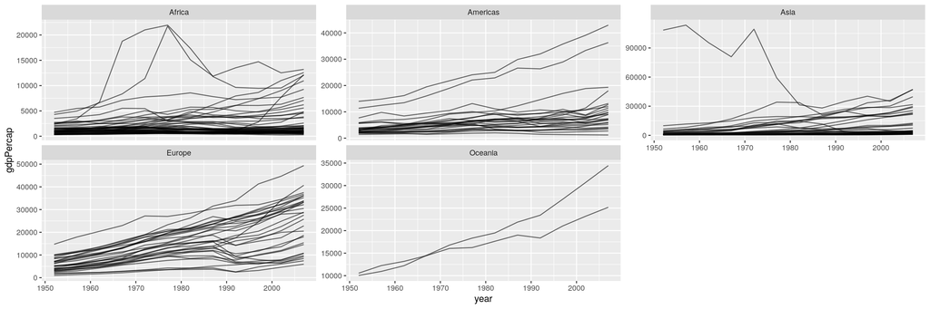

```r
gapminder %>%
  ggplot() +
  aes(x = year, y = gdpPercap, group=country) +
  geom_line(alpha=0.6) +
  facet_wrap(vars(continent),  scales = "free_y")
```

Overall, there’s a positive trend in GDP per capita growth in most continent. From this graph, it appears that countries in Europe and Oceania have a relatively higher growth rate of GDP per capita. Most countries in Asia have a positive GDP per capita growth, except one country (Kuwait) that took a really steep decrease in GDP per capita. It appears that Africa has the lowest level of growth in GDP per capita. Some countries have a good growth rate, but most countries have a low growth rate.